# Exploring and Tagging Text

Chenghao Meng,Chun Gao,Fan Feng,Jiaheng Li,Yinfeng Zhou

2020/11/18

```r
# Load the package
pacman:: p_load(tnum,httr,tidyverse,sentimentr,tidytext)
tnum.authorize(ip="54.158.136.133")
```

# 1 Co-occurence of Elizabeth and Darcy

## 1.1 Data Preparation and Cleaning

```r
# Take a glance at the db
pride_text <- tnum.getDatabasePhraseList("subject",level=3)
#pride_text
```

First, we will tag the sentences with the occurence of Elizabeth and Darcy.

```r
# Tag "Elizabeth"
tnum.tagByQuery("*pride* has text= REGEXP(\"Elizabeth\")","reference:Group9Elizabeth" )
```

```
## list(modifiedCount = 610, tagged = 610, removed = 0)
```

```r
# Tag Darcy
tnum.tagByQuery("*pride* has text= REGEXP(\"Darcy\")","reference:Group9Darcy" )
```

```
## list(modifiedCount = 394, tagged = 394, removed = 0)
```

After that, we will generate a dataframe with the occurence of Darcy based our tag.

Then, we will use the `filter` function in the `tidyverse` package to get the dataframe of sentences with the co-occurence of Elizabeth and Darcy.

```r
# Dataframe with the occurance of Darcy
qdarcy <- tnum.query("@reference:Group9Darcy",max=394)
```

```
## Returned 1 thru 394 of 394 results
```

```r
darcy_df <- tnum.objectsToDf(qdarcy)
#head(darcy_df)

# Dataframe: Co-occurence of Elizabeth and Darcy
co_occur <- filter(darcy_df,grepl('Group9Elizabeth',tags))
```

## 1.2 Explortary Data Analysis

### 1.2.1 Tree Plot

Using the **co_occur** dataframe, a tree plot will be generated to visualize the co-occurence of Elizabeth and Darcy in different chapters and sentences within the *Pride and Prejudice*.

```r
# Tree plot
plot_tree_co_occr=tnum.makePhraseGraphFromPathList(co_occur$subject)
tnum.plotGraph(plot_tree_co_occr)
```

[interactive chart not shown]

### 1.2.2 Distribution of Co-occurence

The tree plot gives us a sense that Elizabeth and Darcy have appeared together in a lot of chapters in *Pride and Prejudice*. However, we are still not sure of the distribution of their co-occurence in different chapters. As a result, we will continue exploring the dataframe **co_occur**.

```r
# Get the info of chapter,paragraph,sentence
co_occur_info <- co_occur %>%
  separate(subject,c("book","chapter","paragraph","sentence"),sep="/") %>%
  select(book,chapter,paragraph,sentence,string.value)
```

When having the information of the chapter, paragraph and sentence of their co-occurence in the book, we will explore their top 10 co-occurence in different chapters

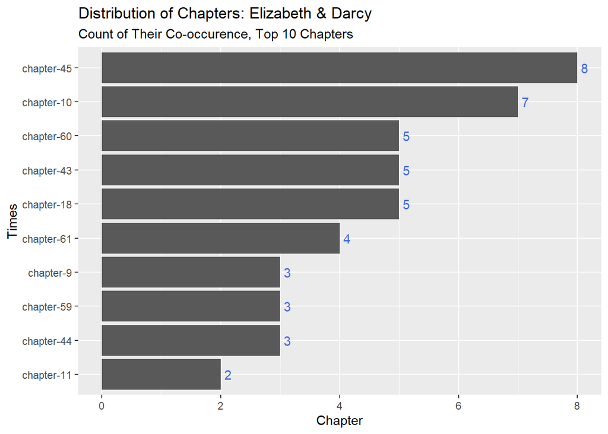

```r
# Top 10 co-occurence in chapters
co_occur_info %>% group_by(chapter) %>%
  summarise(times=n()) %>%
  arrange(desc(times)) %>% head(10) %>%

  ggplot() +
  geom_bar(aes(x=reorder(chapter,times),y=times),stat = "identity") +
  geom_text(aes(x=reorder(chapter,times),y=times,label=times),hjust=-0.5,col="royalblue") +
  xlab("Times") + ylab("Chapter") +
  ggtitle("Distribution of Chapters: Elizabeth & Darcy",subtitle = "Count of Their Co-occurence, Top 10 Chapters") +
  coord_flip()
```

The bar plot shows that Elizabeth and Darcy appears together 8 times in chapter 45, which is the largest number of their co-occurence.

We also have the interest to explore how the counts of these sentences with their co-occurence are distributed by chapter.

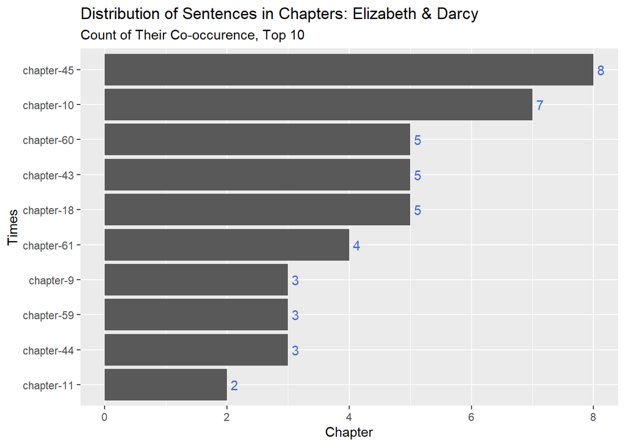

```r
co_occur_info %>% group_by(chapter,paragraph,sentence) %>%
  summarise(times=n()) %>% group_by(chapter)%>%
  summarise(sum_times=sum(times))%>%
  arrange(desc(sum_times)) %>% head(10) %>%


ggplot() +
  geom_bar(aes(x=reorder(chapter,sum_times),y=sum_times),stat = "identity") +
  geom_text(aes(x=reorder(chapter,sum_times),y=sum_times,label=sum_times),hjust=-0.5,col="royalblue") +
  xlab("Times") + ylab("Chapter") +
  ggtitle("Distribution of Sentences in Chapters: Elizabeth & Darcy",subtitle = "Count of Their Co-occurence, Top 10") +
  coord_flip()
```

We find out that in each sentence, there is at most 1 co-occurence of `Darcy` and `Elizabeth`. Therefore, the distribution of co-occurence sentences is the same as the previous distribution.

# 2 Money-related Information

After exploring the co-occurence of Elizabeth and Darcy, we would also like to explore the money-related information in the *Pride and Prejudice*.

## 2.1 Data Preparation

We will use the regular expression to get the sentences relating to money in the query to produce a dataframe.

```r
# Dataframe-money_df
#tnum.tagByQuery("*pride* has text == REGEXP(\"money\")", "reference:Group9money")
qmoney <- tnum.query("*pride* has * = REGEXP(\"money\")",max=1000)
```

```
## Returned 1 thru 25 of 25 results
```

```r
money_df <- tnum.objectsToDf(qmoney)
```

## 2.2 Explortary Data Analysis

### 2.2.1 Tree Plot

```r
#Tree plot of money

# plot_tree_money <- tnum.makePhraseGraphFromPathList(tnum.getAttrFromList(qmoney,"subject"))
plot_tree_money<-tnum.makePhraseGraphFromPathList(money_df$subject)
tnum.plotGraph(plot_tree_money)
```

[interactive chart not shown]

The tree plot shows that money seems not to be a word that occurs many times in the book. Only 13 chapters contain the word “money”.

## 2.2.2 Sentiment Score

Moreover, we would also like to know what is the sentiment when the word money appears in the sentence. And we will use the `sentiment_by` function in `sentimentr` package to compute the sentiment score of each sentence.

```r
money_df2 <- money_df %>%
  separate(subject,c("book","chapter","paragraph","sentence"),sep="/") %>%
  select(chapter,paragraph,sentence,string.value) %>%
  rename(text=string.value) %>%
  # Delete stop words
  filter(!text %in% stop_words$word)

# Delete the "" in the text
money_df2$text <- gsub("\"","",money_df2$text)
```

```r
# Insert an empty column-senti_score
money_df2$senti_score <- rep(NA,times=nrow(money_df2))

# Compute sentiment score
for (i in 1:nrow(money_df2)) {
  sentences <- get_sentences(money_df2$text[i])
  money_df2$senti_score[i] <- sentiment_by(sentences)$ave_sentiment
}
```

After computing the sentiment score, we will draw a line chart to visualize the trend of sentiment score across the chapters that the word money appears.

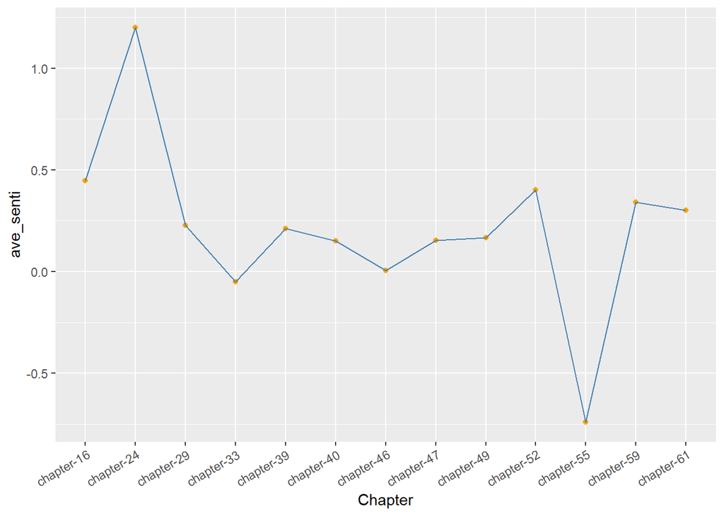

```r
money_senti <- money_df2 %>% group_by(chapter) %>%
  summarise(ave_senti=mean(senti_score)) %>%
  arrange(desc(ave_senti))

# Plot the sentiment score
ggplot(data = money_senti,aes(x=chapter,y=ave_senti,group=1)) +
  geom_point(col="orange")+
  geom_line(col="steelblue")+
  xlab("Chapter")  +theme(axis.text.x = element_text(angle = 30, hjust = 1))
```

```r
  ggtitle("Sentiment Trend of Money-appearing Chapter")
```

```
## $title
## [1] "Sentiment Trend of Money-appearing Chapter"
##
## attr(,"class")
## [1] "labels"
```